# Data Preparation

This folder contains instructions and the code to create the z-scores used for analysis in the “Gene expression analysis in the ADEPTUS database” and “Gene expression analysis of ulcerative colitis” sections of the paper.

To reproduce the results found in the above-mentioned sections of the paper, you can use the already processed data, in which case you only need to run the analyses described in the files **AdeptusDataAnalysis.html** and **UlcerativeColitisDataAnalysis.html** with the following input data:

- **ZmatrixForAdeptusDataAnalysis.Rdata** (readable by R) contains the z-scores for the 20 studies analysed in the “Gene expression analysis in the ADEPTUS database” section of the paper.
- **ZmatrixForUlcerativeColitisDataAnalysis.Rdata** (readable by R) contains the z-scores for the discovery meta-analysis study and the validation meta-analysis study analysed in the “Gene expression analysis of ulcerative colitis” section of the paper.

## Preparing **ZmatrixForAdeptusDataAnalysis.Rdata**

Prepare the data yourself by downloading **gene_dataset_p_matrices.RData** from the **ADEPTUS** website http://adeptus.cs.tau.ac.il/downloads and running the following R code chunk.

```r
load("gene_dataset_p_matrices.Rdata")

#find the number of unique studies
fullstudyname = NULL
for(i in 1:length(gene_dataset_p_matrices)){
fullstudyname = c(fullstudyname, names(gene_dataset_p_matrices[[i]]))
}
print(length(fullstudyname))#1925 studies
```

```
## [1] 1925
```

```r
K = length(unique(fullstudyname))#149 unique studies.
print(K)
```

```
## [1] 149
```

```r
#number of genes
m = dim(gene_dataset_p_matrices[[1]][[1]])[1]
print(m)
```

```
## [1] 10081
```

```r
#put the one-sided p-values for each study into an mXK matrix
pvmat = matrix(NA, nrow = m, ncol =K)
pvmat2sided = matrix(NA, nrow = m, ncol =K)
ufullstudyname = unique(fullstudyname)
uindex = 0
colnamespvmat = NULL
for(i in 1:length(gene_dataset_p_matrices)){
  l = gene_dataset_p_matrices[[i]]
  if(length(l)==0){next}
  for(j in 1:length(l)){
    if (match(names(l)[j], ufullstudyname)>uindex){
      uindex = uindex+1
      pvmat[,uindex] = l[[j]][,2]
      pvmat2sided[,uindex] = l[[j]][,1]
      colnamespvmat = c(colnamespvmat, names(l)[j])
    }
  }
}
colnames(pvmat) = colnamespvmat

#transfrom the pvalue matrix to a z-score matrix, putting -10 instead of -infinity (one-sided pvalue on zero) and 10 instead of infinity (one-sided pvalue of one)
zvmat =qnorm(pvmat)
for (i in 1:dim(pvmat)[2]){
     sub = which(zvmat[,i]<(-10))
     zvmat[sub,i] = -10
     sub = which(zvmat[,i]>(10))
     zvmat[sub,i] = 10
}
#in order to select a subset of studies that are not too sparse (estimated fraction of nonnulls at least 0.15, so est-OMT-FDR and est-OMT-pFDR likely to coincide and we shall only consider est-OMT-FDR in the analysis) or too dense (estimated fraction of nonnulls at most 0.4, since otherwise suspect the theoretical null is problematic) and with values not too extreme (exclude studies with pvalues exactly zero or one for simplicity), we compute the conservative version of storey's plug-in estimator for each study, with parameter lambda = 0.05, as well as the number of pvalues at zero or one.
pimat = NULL
for (i in 1:dim(zvmat)[2]){
     zv = zvmat[,i]
     pv = pvmat[,i]
     p0storey = (sum(2*pmin(pv, 1-pv)>0.05)+1)/(m*0.95)
     pimat = rbind(pimat, c(i, 1-p0storey, sum(zv==10), sum(zv==-10)))
}
print(head(pimat))
```

```
##      [,1]       [,2] [,3] [,4]
## [1,]    1 0.54829043   88    6
## [2,]    2 0.79910097 1706 1246
## [3,]    3 0.53701335   52    0
## [4,]    4 0.27273297    0    0
## [5,]    5 0.03027582    0    0
## [6,]    6 0.25519085    0    0
```

```r
pimatsub = pimat[pimat[,2]>=0.15 & pimat[,2]<=0.4 & pimat[,3]==0 & pimat[,4]==0,]
print(dim(pimatsub))
```

```
## [1] 20  4
```

```r
print(ufullstudyname[pimatsub[,1]])
```

```
##  [1] "GSE3790"  "GDS3459"  "GDS3128"  "GSE60862" "GDS3268"  "GDS4407"
##  [7] "GDS3690"  "GDS3318"  "GDS3057"  "GDS2362"  "GSE15296" "GSE5406"
## [13] "GDS1220"  "GDS4353"  "GSE6481"  "GDS1362"  "GDS4299"  "GDS1975"
## [19] "GDS2771"  "GSE66360"
```

```r
Zmatrix  = zvmat[,pimatsub[,1]]
print(head(Zmatrix))
```

```
##         GSE3790    GDS3459     GDS3128    GSE60862    GDS3268    GDS4407
## [1,]  1.0352483  2.2720687  1.18199711  0.47306203 -0.6601910 -0.6280522
## [2,]  0.1040144  2.4234985  0.31733305 -1.24485679  2.8164156  0.5059888
## [3,]  3.4067709  0.9020913  1.62838632 -0.47151927  0.8531118 -2.4426108
## [4,] -1.2016699 -0.9910921 -0.03282946 -0.50611456  0.5111147 -1.2873528
## [5,] -0.7586946 -3.1185257  2.83427632  1.79385506 -2.5054552 -0.1979956
## [6,] -2.2589403  1.9109444  0.32827557 -0.06090335 -1.5333397  0.5060451
##          GDS3690     GDS3318     GDS3057    GDS2362  GSE15296    GSE5406
## [1,]  0.27946253 -0.06248153  0.94339608  0.7771585 -1.516284  1.3911488
## [2,]  0.06463802 -1.19625278  3.37320926  3.5189145 -0.380488 -0.1262736
## [3,]  2.40871092  0.47960495 -2.15300964 -0.9574351 -1.794579  0.6635118
## [4,]  2.00949558 -1.06866540 -0.08885335  4.1095105 -1.777491 -2.0803025
## [5,] -1.53230397  0.14580477  1.68143650 -1.5418436  3.254025 -0.3210350
## [6,]  0.78705905 -0.06248153  2.24882767 -0.8714674  4.794071  1.5517178
##         GDS1220    GDS4353    GSE6481    GDS1362    GDS4299     GDS1975
## [1,] -1.0024562 -0.6025276  1.5261014 -0.1379727  2.7040249  0.47210683
## [2,]  2.0039754 -3.7182302 -0.7970996 -0.2573693  4.2249013 -1.49260599
## [3,]  3.6829613  2.1364426 -0.2643654 -2.3930880  3.4207544 -2.60848396
## [4,]  0.2521255 -2.6107010 -0.7490333 -1.0184746 -0.3800838  1.59753321
## [5,] -1.5196665 -1.1767341  0.7049744  2.5600085 -2.1556775 -0.06199322
## [6,] -1.5196665 -0.2005982  0.7890865 -0.1533303 -0.1737637 -0.14306198
##         GDS2771    GSE66360
## [1,]  0.2104024  1.10577649
## [2,]  1.3624243  3.11785052
## [3,]  1.3767115 -0.13997128
## [4,] -0.6493908 -1.57467685
## [5,]  2.1637803  0.30443847
## [6,]  0.9702286  0.02799434
```

```r
print(dim(Zmatrix))
```

```
## [1] 10081    20
```

```r
#save(Zmatrix, file ="ZmatrixForAdeptusDataAnalysis.Rdata")
```

## Preparing **ZmatrixForUlcerativeColitisDataAnalysis.Rdata**

```r
validationdat = read.table(file = "ValidationPvaluesUC.csv", sep=",", header=TRUE)
head(validationdat)
```

```
##         ID pfp.DOWNregulated pfp.UPregulated pval.DOWNregulated
## 1     A1BG          1.190489      1.53394909          0.9945830
## 2 A1BG-AS1          1.719456      1.72105583          0.8534986
## 3     A1CF          0.000000      1.07466703          0.0000000
## 4    A2LD1          1.624891      1.84876613          0.9074089
## 5      A2M          1.139611      0.03246433          0.9984908
## 6  A2M-AS1          1.115749      0.18380350          0.9994403
##   pval.UPregulated
## 1      0.457708760
## 2      0.566948179
## 3      0.999965019
## 4      0.765984708
## 5      0.004206686
## 6      0.030476238
```

```r
dim(validationdat)
```

```
## [1] 20011     5
```

```r
discoverydat = read.table(file = "discoveryPvaluesUC.csv", sep=",", header=TRUE)
head(discoverydat)
```

```
##       ID pfp.DOWNregulated pfp.UPregulated pval.DOWNregulated pval.UPregulated
## 1   A1BG         1.2350162       1.1505019         0.99545383       0.36632220
## 2   A1CF         0.0000000       1.0082535         0.00000000       1.00000000
## 3    A2M         1.1743716       0.1142434         0.99925409       0.01868893
## 4  A2ML1         0.5753421       1.2081366         0.15417813       0.99863130
## 5 A4GALT         0.7728168       1.6045631         0.24399149       0.79975966
## 6  A4GNT         0.1795178       1.2062074         0.02999018       0.99869548
```

```r
dim(discoverydat)
```

```
## [1] 15270     5
```

```r
#take only the probes that match both datasets
out = match(validationdat[,1],discoverydat[,1] )
ID = validationdat[!is.na(out),1]
outvalidation = match(ID, validationdat[,1] )
sum(!is.na(outvalidation))
```

```
## [1] 15247
```

```r
head(outvalidation)
```

```
## [1]  1  3  5  7  9 10
```

```r
outdiscovery = match(ID,discoverydat[,1] )
sum(!is.na(outdiscovery))
```

```
## [1] 15247
```

```r
head(outdiscovery)
```

```
## [1] 1 2 3 4 5 6
```

```r
validationdat2 = validationdat[outvalidation,]
discoverydat2 = discoverydat[outdiscovery,]
head(validationdat2)
```

```
##        ID pfp.DOWNregulated pfp.UPregulated pval.DOWNregulated pval.UPregulated
## 1    A1BG          1.190489      1.53394909          0.9945830      0.457708760
## 3    A1CF          0.000000      1.07466703          0.0000000      0.999965019
## 5     A2M          1.139611      0.03246433          0.9984908      0.004206686
## 7   A2ML1          1.292505      1.62282391          0.9826680      0.913228724
## 9  A4GALT          1.583306      1.80354940          0.9231138      0.830077957
## 10  A4GNT          1.648205      1.34088173          0.8976133      0.972743991
```

```r
head(discoverydat2)
```

```
##       ID pfp.DOWNregulated pfp.UPregulated pval.DOWNregulated pval.UPregulated
## 1   A1BG         1.2350162       1.1505019         0.99545383       0.36632220
## 2   A1CF         0.0000000       1.0082535         0.00000000       1.00000000
## 3    A2M         1.1743716       0.1142434         0.99925409       0.01868893
## 4  A2ML1         0.5753421       1.2081366         0.15417813       0.99863130
## 5 A4GALT         0.7728168       1.6045631         0.24399149       0.79975966
## 6  A4GNT         0.1795178       1.2062074         0.02999018       0.99869548
```

```r
#transrom to z-scores the down regulated and up regulated meta-analysis p-values
validationzup = qnorm(validationdat2[,5])
validationzdown = qnorm(validationdat2[,4])
summary(validationzup)
```

```
##    Min. 1st Qu.  Median    Mean 3rd Qu.    Max.
##    -Inf -1.0952  0.9417          2.0248     Inf
```

```r
summary(validationzdown)
```

```
##    Min. 1st Qu.  Median    Mean 3rd Qu.    Max.
##    -Inf -1.2646  0.9373          2.1266     Inf
```

```r
discoveryzup = qnorm(discoverydat2[,5])
discoveryzdown = qnorm(discoverydat2[,4])
summary(discoveryzup)
```

```
##    Min. 1st Qu.  Median    Mean 3rd Qu.    Max.
##    -Inf -0.9338  0.8481          2.3837     Inf
```

```r
summary(discoveryzdown)
```

```
##    Min. 1st Qu.  Median    Mean 3rd Qu.    Max.
##    -Inf -1.1497  0.3838          2.0791     Inf
```

```r
#in order to avoid fittign a mixture model to a z-score vector with entries at -infty and infty (corresponding to meta-analysis pvalues of zero or one), randomly draw a z-score centered at -6 and 6 (with sd of one) to replace a z-score smaller than -6 or greater than 6.
print(c(sum(validationzup>6), sum(validationzup<(-6))))
```

```
## [1] 630 957
```

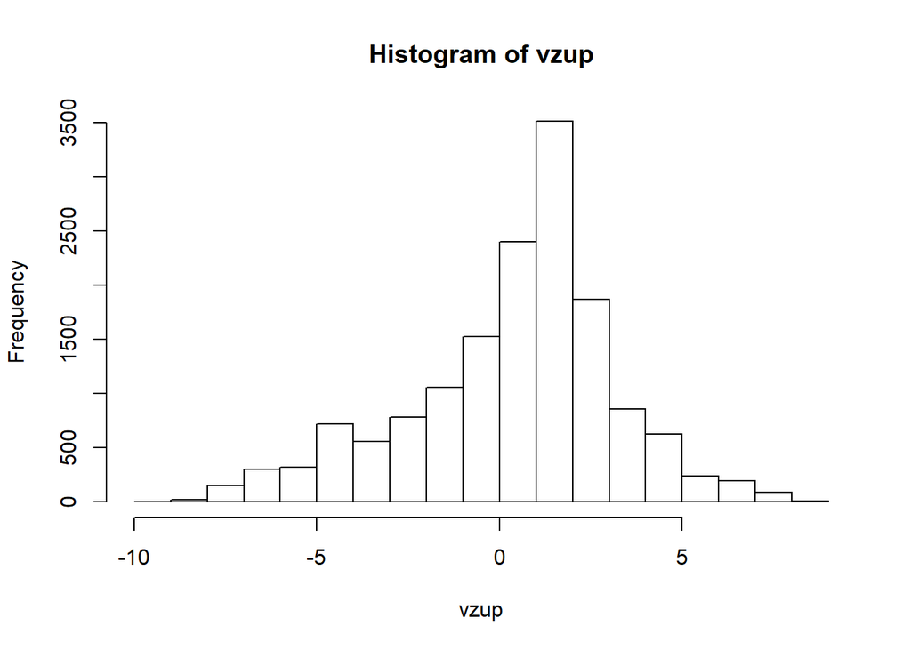

```r
vzup = validationzup
vzup[validationzup>6] =rnorm(sum(validationzup>6),6,1)
vzup[validationzup<(-6)] = rnorm(sum(validationzup<(-6)),-6,1)
hist(vzup)
```

```r
summary(vzup)
```

[output not shown]

```r
print(c(sum(validationzdown>6), sum(validationzdown<(-6))))
```

```
## [1] 912 730
```

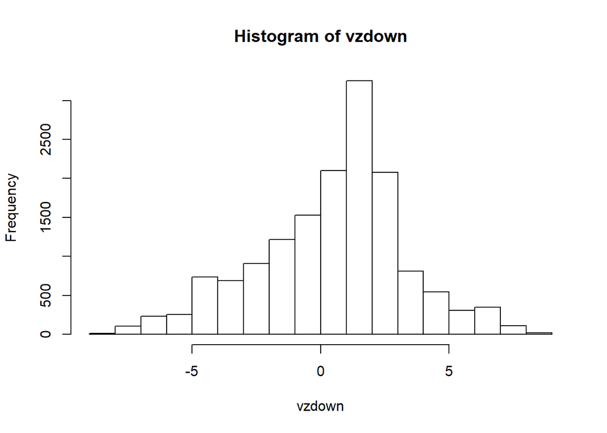

```r
vzdown = validationzdown
vzdown[validationzdown>6] =rnorm(sum(validationzdown>6),6,1)
vzdown[validationzdown<(-6)] = rnorm(sum(validationzdown<(-6)),-6,1)
hist(vzdown)
```

```r
summary(vzdown)
```

```
##    Min. 1st Qu.  Median    Mean 3rd Qu.    Max.
## -8.6609 -1.2646  0.9373  0.4507  2.1266  8.8908
```

```r
print(c(sum(discoveryzup>6), sum(discoveryzup<(-6))))
```

```
## [1] 747 922
```

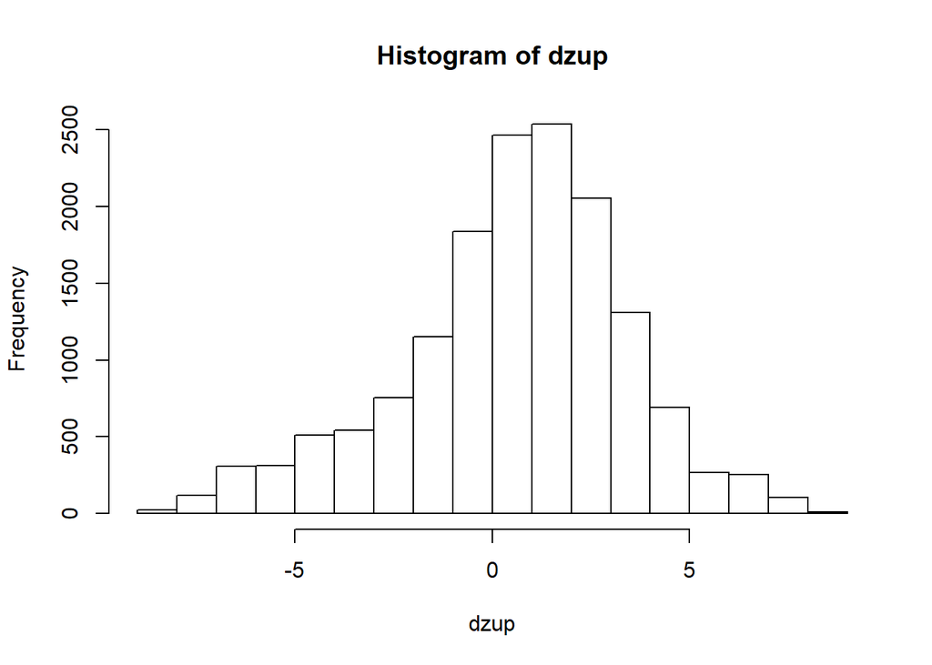

```r
dzup = discoveryzup
dzup[discoveryzup>6] =rnorm(sum(discoveryzup>6),6,1)
dzup[discoveryzup<(-6)] = rnorm(sum(discoveryzup<(-6)),-6,1)
hist(dzup)
```

```r
summary(dzup)
```

```
##    Min. 1st Qu.  Median    Mean 3rd Qu.    Max.
## -8.9813 -0.9338  0.8481  0.5427  2.3837  8.7127
```

```r
print(c(sum(discoveryzdown>6), sum(discoveryzdown<(-6))))
```

```
## [1] 595 521
```

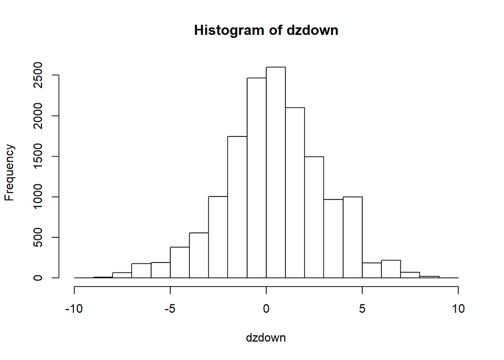

```r
dzdown = discoveryzdown
dzdown[discoveryzdown>6] =rnorm(sum(discoveryzdown>6),6,1)
dzdown[discoveryzdown<(-6)] = rnorm(sum(discoveryzdown<(-6)),-6,1)
hist(dzdown)
```

```r
summary(dzdown)
```

```
##    Min. 1st Qu.  Median    Mean 3rd Qu.    Max.
## -9.2149 -1.1497  0.3838  0.4284  2.0791  9.8930
```

```r
Zmatrix = data.frame(dzup = dzup, dzdown = dzdown, vzup = vzup, vzdown = vzdown)

#save(Zmatrix, file ="ZmatrixForUlcerativeColitisDataAnalysis.Rdata")
```